# Introduction to Amazon Dataset

Alena Suvorova

11 04 2017

## Данные

Общий датасет включает данные Amazon.com (отзывы и метаданные), всего 142.8 миллионов отзывов за период с мая 1996 по июль 2014.

Данные состоят из трех разделов: отзывы (текст отзыва, его полезность, поставленная в нем оценка, автор отзыва, продукт, на который написан отзыв); метаданные продукта (описание, информация о категориях товара, рейтинг, цена, бренд); и рекомендации Амазона (с эти товаром покупают, с этим товаром также смотрят).

Подробности http://jmcauley.ucsd.edu/data/amazon/. Мы работаем с категорией *Фильмы и ТВ*.

## Загрузка данных

Данные представлены в формате JSON, как выглядит, например, записсь о первом отзыве:

```
## [1] "{\"reviewerID\": \"A345WVAVMMO6F0\", \"asin\": \"0767800761\", \"reviewerName\": \"Jonathan Lapin \\\"fletcher rabbit\\\"\", \"helpful\": [0, 0], \"reviewText\": \"one of those movies that is just a guilty pleasure. i KNOW its not very good, but the casual sex and drug use is a hoot to watch…
## [2] "{\"reviewerID\": \"A1NI0VOVXZBM7Y\", \"asin\": \"0767800761\", \"reviewerName\": \"Jose Lopez \\\"Jose Lopez\\\"\", \"helpful\": [1, 1], \"reviewText\": \"Thank God It's Friday:I was surprised I thought it was a funny movie, \\\"You D**n Right your Sorry\\\"-The short Garbage man, and Donna …
```

где

- reviewerID - ID автора отзыва, например, A345WVAVMMO6F0
- asin - ID продукта, например, 0767800761
- reviewerName - имя автора отзыва
- helpful - полезность отзыва (два числа: сколько раз этот отзыв посчитали полезным и сколько раз его оценили всего)
- reviewText - текст отзыва
- overall - оценка в отзыве
- summary - заголовок отзыва
- unixReviewTime - время отзыва (unix time)
- reviewTime - время отзыва (raw)

Тот же самый [отзыв](https://www.amazon.com/gp/customer-reviews/R1V3UJQQMEINAN/ref=cm_cr_getr_d_rvw_ttl?ie=UTF8&ASIN=0767800761) на сайте

Чтобы преобразовать данные (разобрать, “распарсить”) из такого формата в привычную таблицу, мы используем библиотеку `jsonlite`.

```r
library(jsonlite)
library(stringr)
```

Чтение и преобразование данных

```r
j = readLines("~/shared/minor2_2016/data/reviews_Movies_and_TV_5_sub1.json") %>%
  str_c(collapse = ",") %>%
  (function(str) str_c("[", str, "]")) %>%
  fromJSON(simplifyDataFrame = T)
```

Посмотрим на данные

```r
head(j, n=3)
```

```
##       reviewerID       asin                     reviewerName helpful
## 1 A345WVAVMMO6F0 0767800761 Jonathan Lapin "fletcher rabbit"    0, 0
## 2 A1NI0VOVXZBM7Y 0767800761          Jose Lopez "Jose Lopez"    1, 1
## 3 A2R4XG0L7Z01V8 0767811100                             <NA>    2, 7
##                                                                                                                                                                                                                                                                                                          …
## 1                                                                                                                                                                                                                                                                                                        …
## 2                                                                                                                                                                                                                                                                                                        …
## 3 I bought this film, thinking it would be an interesting insight into the world of an obsessive compulsive, played by Jack Nicholson. Don't ask me why it interests me, but I definitely think everyone has a little obsessiveness in them somewhere - I know I certainly do.Instead, what did I get? A …
##   overall                                  summary unixReviewTime
## 1       3 anybody else missing casual sex & drugs?     1162771200
## 2       3                   Thank God It's Friday.     1277510400
## 3       3 Obsessive compulsive when it wants to be     1124150400
##    reviewTime
## 1  11 6, 2006
## 2 06 26, 2010
## 3 08 16, 2005
```

И обратим внимание на структуру

```r
str(j, max.level = 1)
```

```
## 'data.frame':    3421 obs. of  9 variables:
##  $ reviewerID    : chr  "A345WVAVMMO6F0" "A1NI0VOVXZBM7Y" "A2R4XG0L7Z01V8" "A3Q1FVRV0CRYTH" ...
##  $ asin          : chr  "0767800761" "0767800761" "0767811100" "0767811100" ...
##  $ reviewerName  : chr  "Jonathan Lapin \"fletcher rabbit\"" "Jose Lopez \"Jose Lopez\"" NA "Damian Gunn \"The Dark One is I\"" ...
##  $ helpful       :List of 3421
##   .. [list output truncated]
##  $ reviewText    : chr  "one of those movies that is just a guilty pleasure. i KNOW its not very good, but the casual sex and drug use is a hoot to watc"| __truncated__ "Thank God It's Friday:I was surprised I thought it was a funny movie, \"You D**n Right your Sorry\"-The short Garbage man, and …
##  $ overall       : num  3 3 3 5 3 4 5 4 5 5 ...
##  $ summary       : chr  "anybody else missing casual sex & drugs?" "Thank God It's Friday." "Obsessive compulsive when it wants to be" "I'm speachless" ...
##  $ unixReviewTime: int  1162771200 1277510400 1124150400 1145318400 1211760000 1110326400 1090972800 1326499200 1075852800 1116288000 ...
##  $ reviewTime    : chr  "11 6, 2006" "06 26, 2010" "08 16, 2005" "04 18, 2006" ...
```

## Исследование данных

#### Оценки

Посмотрим, склонны ли пользователи писать позитивные отзывы (отзывы с высокими оценками)

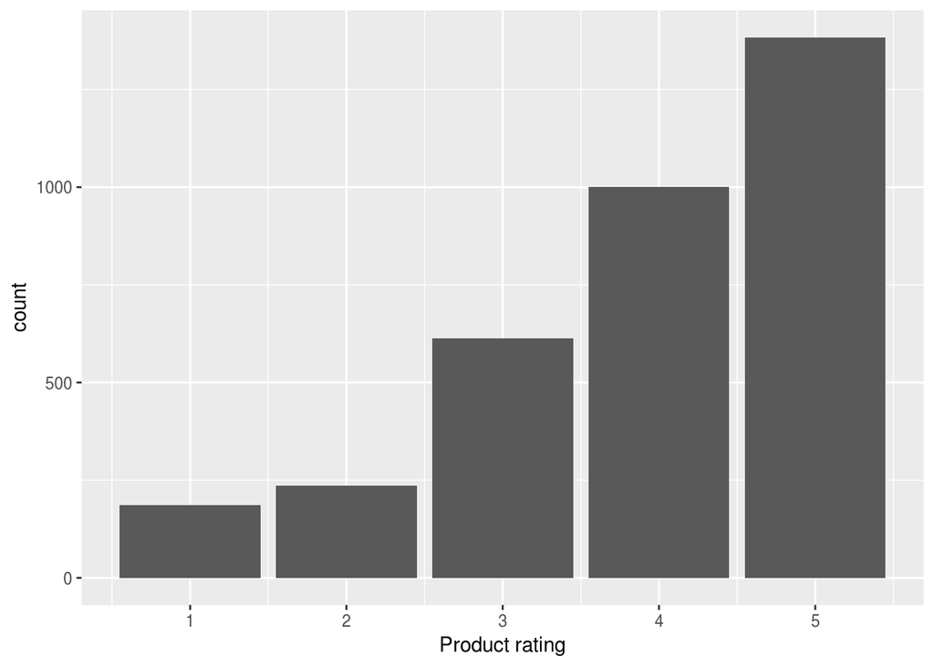

```r
library(ggplot2)
ggplot(data = j) + geom_bar(aes(x=overall)) + xlab("Product rating")
```

Средние оценки, поставленные каждому товару (из нашего сокращенного датасета). Какие выводы можно сделать?

```r
library(dplyr)
```

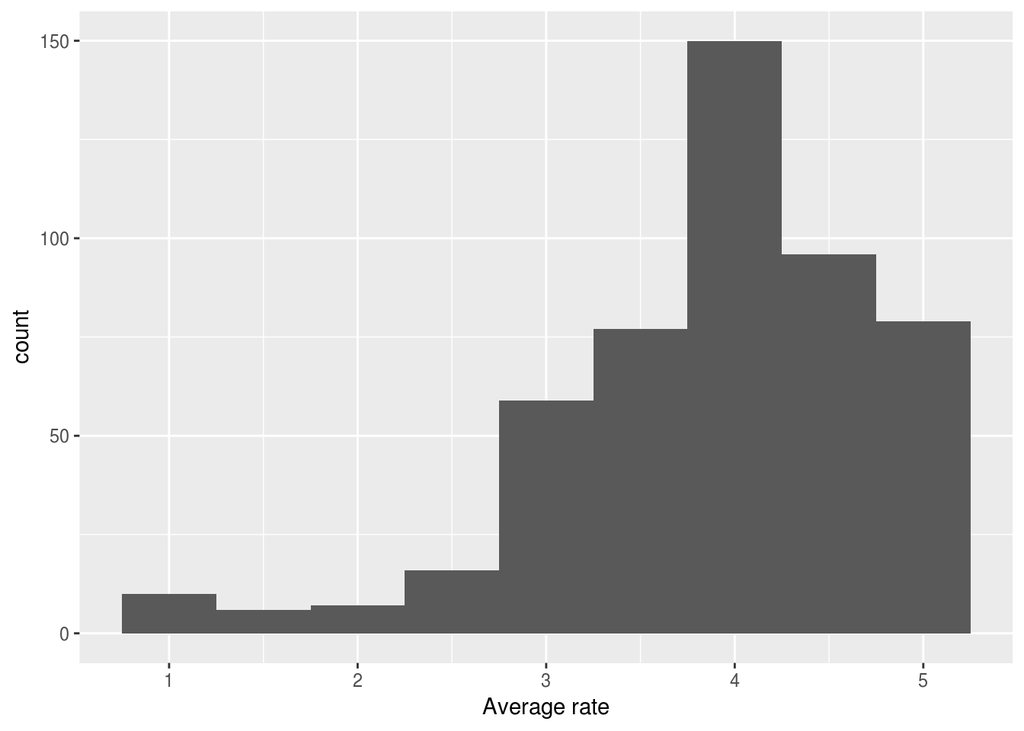

```r
j2 <- j %>% group_by(asin) %>% summarise(rate = mean(overall))
ggplot(data = j2) + geom_histogram(aes(x=rate), binwidth = 0.5) + xlab("Average rate")
```

#### Полезность

Проверим, был ли отзыв **полезным**

```r
head(j$helpful)
```

```
## [[1]]
## [1] 0 0
##
## [[2]]
## [1] 1 1
##
## [[3]]
## [1] 2 7
##
## [[4]]
## [1] 19 19
##
## [[5]]
## [1] 2 4
##
## [[6]]
## [1] 3 4
```

Сейчас это пара чисел: сколько раз этот отзыв посчитали полезным и сколько раз его оценили всего. Преобразуем данные к доле отметок “полезный” в общем числе отметок.

```r
helpf <- unlist(j$helpful)
head(helpf)
```

```
## [1] 0 0 1 1 2 7
```

После такого преобразования каждое число на нечетной позиции (1, 3, 5, …) – это количество голосов “да, отзыв был полезным” , каждое число на четной позиции – число голосов всего. Разделим значения на два вектора

```r
yes <- rep(c(T,F), length(j$helpful))
j$helpful_yes <- helpf[yes]
j$helpful_total <- helpf[!yes]
```

Сколько всего в голосов получили отзывы

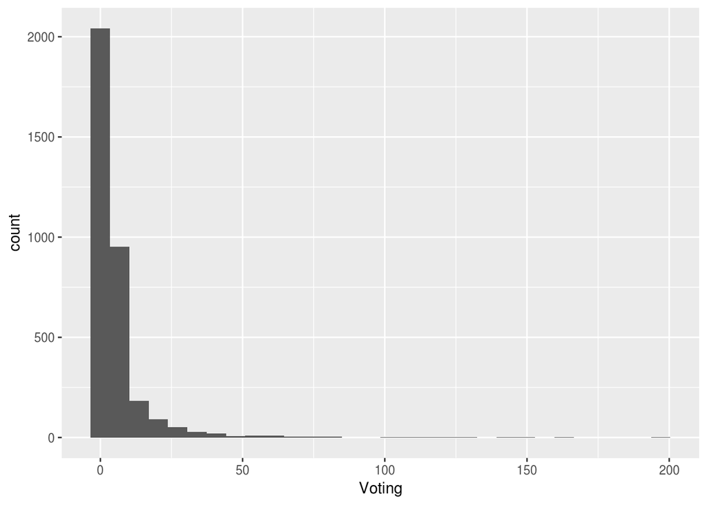

```r
ggplot(data = j) + geom_histogram(aes(x=helpful_total)) + xlab("Voting")
```

```r
n <- dim(j)[1] # number of reviews
```

Доля отзывов без голосов

```r
sum(j$helpful_total==0)/n
```

```
## [1] 0.1905875
```

Доля отзывов с более 10 голосами

```r
sum(j$helpful_total>10)/n
```

```
## [1] 0.1242327
```

Посчитаем полезность (долю голосов “за”). Отобразим результаты для отзывов, получивших более 10 голосов. Какие выводы можно сделать?

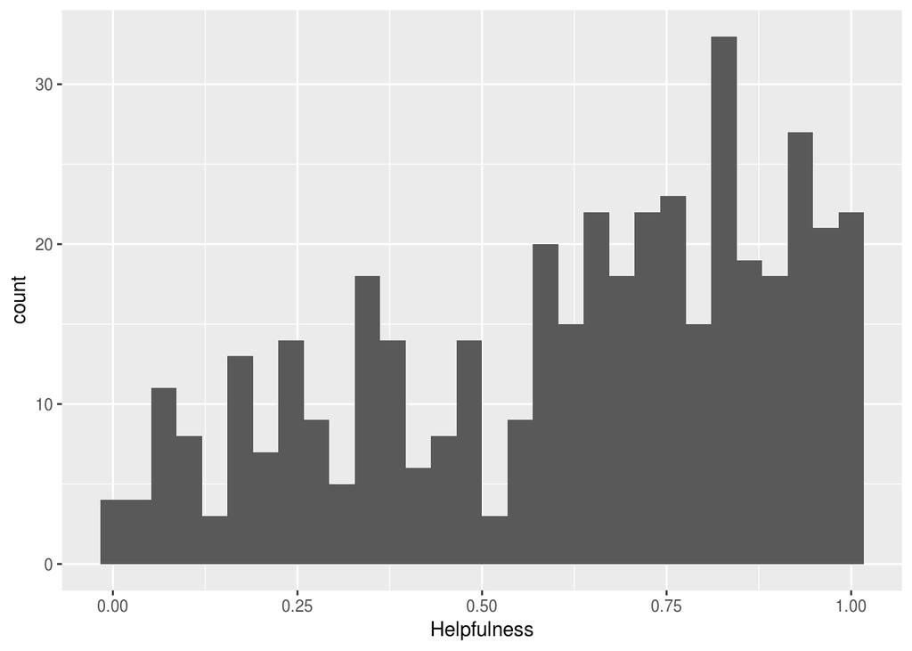

```r
## helpfullness ratio
j$helpfulness[j$helpful_total>0] <- j$helpful_yes[j$helpful_total>0]/j$helpful_total[j$helpful_total>0]

ggplot(data = j[j$helpful_total>10,]) + geom_histogram(aes(x=j$helpfulness[j$helpful_total>10])) + xlab("Helpfulness")
```

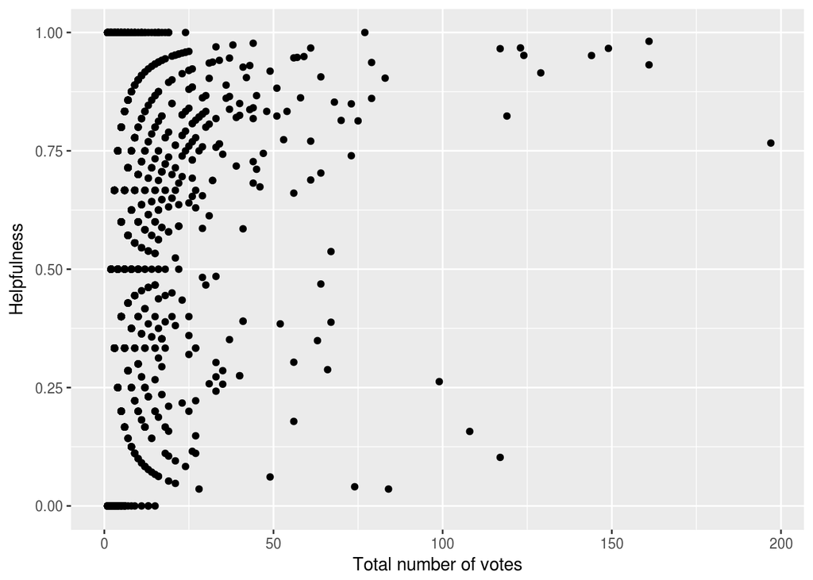

```r
ggplot(data = j) + geom_point(aes(x=j$helpful_total, y = j$helpfulness)) + ylab("Helpfulness") + xlab("Total number of votes")
```

Можно отобразить и изменение полезности в отзывах с разными оценками

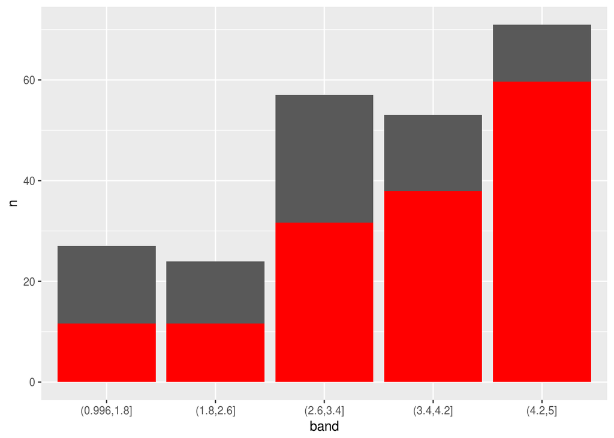

```r
j10 = j[j$helpful_total>10,]
j10  %>% group_by(asin)  %>% summarise(overall=mean(overall), hy=sum(helpful_yes), ht=sum(helpful_total))  %>%
  mutate(band = cut(overall, 5))  %>%
  group_by(band)  %>%  summarise(n = n(), prophelp = sum(hy)/sum(ht))   %>%
  ggplot() + geom_bar(aes(band, n), stat="identity") + geom_bar(aes(band, n*prophelp), fill="red", stat="identity")
```

#### Даты и время

Посмотрим, как изменяется число отзывов и их полезность с течением времени. Какие особенности можно заметить?

```r
library(lubridate)
```

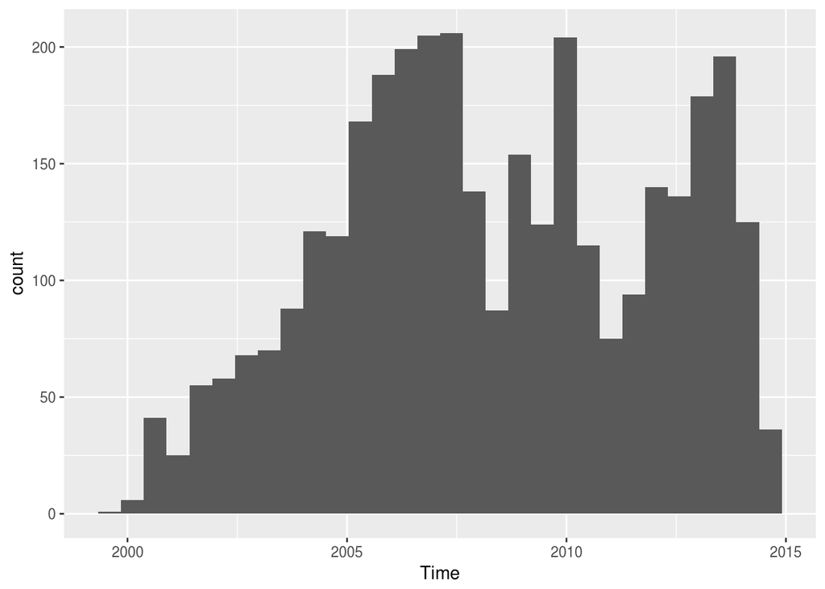

```r
j$reviewTime<-mdy(j$reviewTime)

ggplot(data = j) + geom_histogram(aes(x=j$reviewTime)) + xlab("Time")
```

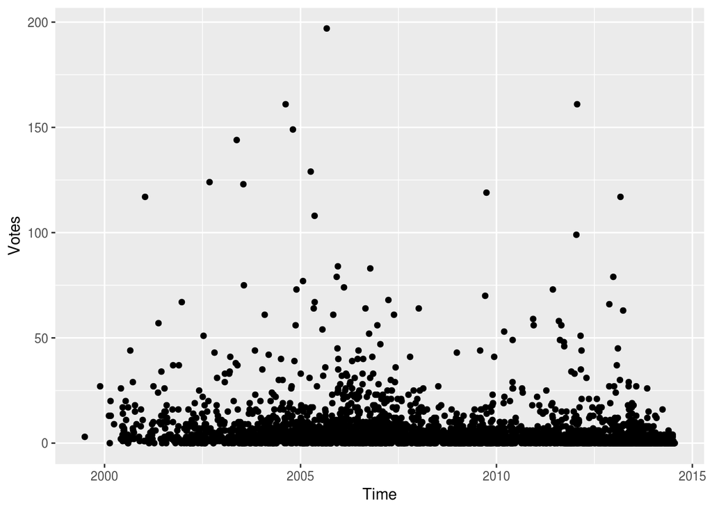

```r
ggplot(data = j) + geom_point(aes(x=j$reviewTime, y = j$helpful_total)) + ylab("Votes") + xlab("Time")
```

# Создание сети

В данном случае будем работать с бимодальными (bipartite) сетями. Бимодальная сеть – это сеть, где вершины двух типов (в нашем случае – фильмы и авторы отзывов), а связи могут быть только между вершинами разных типов. Для создания бимодальной сети нужно указать, что у есть два типа вершин.

```r
reviewers <- data.frame(name = unique(j$reviewerID), type=T)
items <- data.frame(name = unique(j$asin), type=F)
nodes <- rbind(reviewers, items)
```

Что является связью между вершинами?

```r
edges = data.frame(from=j$reviewerID, to=j$asin)
head(edges)
```

```
##             from         to
## 1 A345WVAVMMO6F0 0767800761
## 2 A1NI0VOVXZBM7Y 0767800761
## 3 A2R4XG0L7Z01V8 0767811100
## 4 A3Q1FVRV0CRYTH 0767811100
## 5  AWG2O9C42XW5G 0767811100
## 6 A2VD3CYOEMJ6SR 0767811100
```

С каким представлением графа мы имеем дело (матрица смежности, список ребер)?

```r
library(igraph)
g <- graph_from_data_frame(edges, directed=TRUE, vertices=nodes)
g
```

```
## IGRAPH DN-B 864 3421 --
## + attr: name (v/c), type (v/l)
## + edges (vertex names):
##  [1] A345WVAVMMO6F0->0767800761 A1NI0VOVXZBM7Y->0767800761
##  [3] A2R4XG0L7Z01V8->0767811100 A3Q1FVRV0CRYTH->0767811100
##  [5] AWG2O9C42XW5G ->0767811100 A2VD3CYOEMJ6SR->0767811100
##  [7] ABN5K7K1TM1QA ->0767811100 A2VJ80PM1G00QV->0767811100
##  [9] A2TDK8D4HEMUYW->0767811100 A3LZGLA88K0LA0->0767811100
## [11] A3TSPLFYU2UMW0->0767811100 A1M3NVR8A3O627->0767811100
## [13] A3FL6CIO8QIJ2F->0767811100 A1NI0VOVXZBM7Y->076781214X
## [15] A2R4XG0L7Z01V8->076781214X A2I6MHMAZZDCRX->076781214X
## + ... omitted several edges
```

Т.к. вершины у нас разных типов, то мы создали бимодальную сеть.

### Сохранение объектов R

Мы можем сохранять любые объекты R в файл и загружать их для работы позже. В этом случае не нужно будет повторять все операции по очистке предобработке данных, построению графа, что важно при работе с объемными датасетами.

```r
#save(g, file = "initialGraph.RData")
load(file = "initialGraph.RData")
```

Для загрузки данных позже используйте ‘load(“initialGraph.RData”)’. После выполнения этой функции объект ‘g’ появится в окружении (environment).